# HaVu_hw4

Vu Thi-Hong-Ha

March 13, 2020

## Question 1:

We have:
$$X_{n \times p} = A_{n \times (g+1)}\beta_{(g+1) \times p} + \epsilon_{n \times p}$$
and
$$\hat{\beta}_{g \times p} = (A'_{g \times n}A_{n \times g})^{-1}A'_{g \times n}X_{n \times g}$$
Then,
$$X_k = A\beta_k + \epsilon_k$$

$$\hat{\beta}_{k} = (A'A)^{-1}A'X_{k}$$
Therefore,
$$\mathbf{E}[ \hat{\beta}_k ] = \mathbf{E}[(A'A)^{-1}A'X_{k}] = (A'A)^{-1}A'\mathbf{E}[X_k]$$

$$\mathbf{E}[X_k] = \mathbf{E}[A\beta_k + \epsilon_k] = \mathbf{E}[A\beta_k] + \mathbf{E}[\epsilon_k] = \mathbf{E}[\epsilon_k]$$
because $A\beta_k$ is a constant matrix so $\mathbf{E}[A\beta_k] = A\beta_k$.
As $\epsilon_k \sim N(0, \Sigma_k)$, $\mathbf{E}[\epsilon_k] = 0$, and $\mathbf{E}[X_k] = A\beta_k$.
Hence,
$$\mathbf{E}[ \hat{\beta}_k ] = (A'A)^{-1}A'A\beta_k = \beta_k$$
Next,
$$Var[\hat{\beta}_k] = Var[(A'A)^{-1}A'X_{k}] = (A'A)^{-1}A'Var(X_{k})[(A'A)^{-1}A']'$$

$$Var[X_k] = Var[A\beta_k + \epsilon_k] = Var[\epsilon_k] = \sigma_{kk}$$
Hence,
$$Var[\hat{\beta}_k] = (A'A)^{-1}A'\sigma_{kk}[(A'A)^{-1}A']' = (A'A)^{-1}A'[(A'A)^{-1}A']'\sigma_{kk} = (A'A)^{-1}A'A[(A'A)^{-1}]'\sigma_{kk} = \sigma_{kk}(A'A)^{-1}$$
Next,
$$cov(\hat{\beta}_k, \hat{\beta}_i) = cov((A'A)^{-1}A'X_{k}, (A'A)^{-1}A'X_{i}) = (A'A)^{-1}A'\mathbf{E}[(X_k - \mathbf{E}(X_k))(X_i - \mathbf{E}(X_i)) ][(A'A)^{-1}A']' = (A'A)^{-1}A'\sigma_{ki}[(A'A)^{-1}A']' = \sigma_{ki}(A'A)^{-1}$$

## Question 2:

*a)*

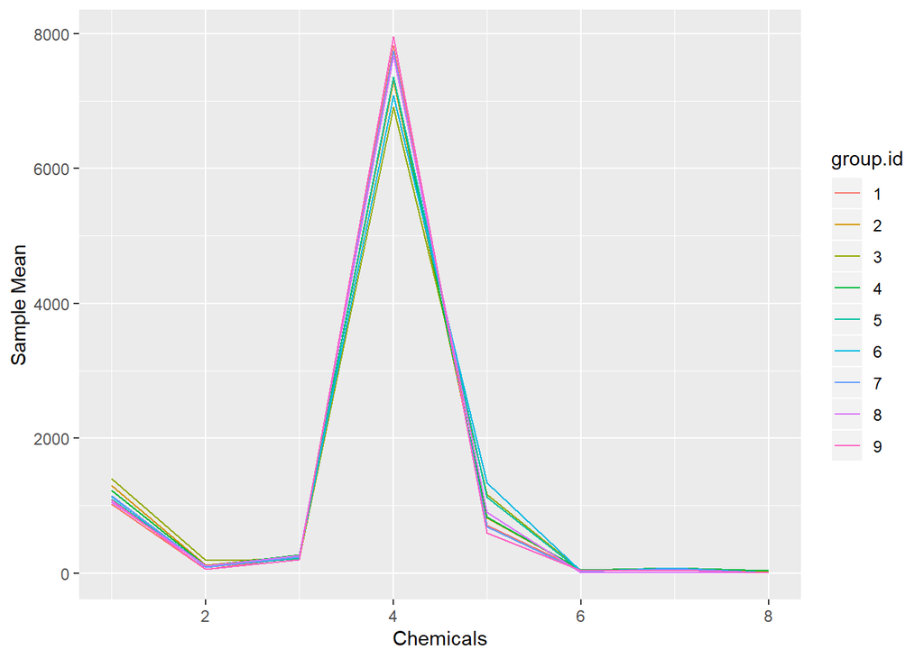

```r
olive <- read.table("D:/Coursework/Stat 501 Spring 2020/Homework3/olive.dat", header = T)

##a
temp <- olive %>% group_by(group.id) %>% summarise_all(mean)
temp <- temp[,-1]
data <- data.frame(matrix(ncol = 3, nrow = 9*8))
colnames(data) <- c("group.id", "chemical", "sampleMean")
data$group.id <- as.character(c(rep(1, 8), rep(2, 8), rep(3, 8), rep(4, 8), rep(5, 8),
                                rep(6, 8), rep(7, 8), rep(8, 8), rep(9, 8)))
data$chemical <- rep(c("1", "2", "3", "4", "5", "6", "7", "8"), 9)
data$sampleMean <- as.numeric(c(temp[1,], temp[2,], temp[3,], temp[4,], temp[5,], temp[6,],
                                temp[7,], temp[8,], temp[9,]))

ggplot(data = data, aes(x=as.numeric(chemical), y=sampleMean, color=group.id)) + geom_line() +
  xlab("Chemicals") + ylab("Sample Mean")
```

From the plot we can see that some chemicals have similar mean compositions across all regions, but some have very distinctive impacts (chemical X1, X4 and X5, for example).

*b)*

```r
olive$region <- NA
for (i in 1:nrow(olive)) {
  if (olive$group.id[i] == "1" | olive$group.id[i] == "2" | olive$group.id[i] == "3" | olive$group.id[i] == "4") {
    olive$region[i] = "R1"
  }
  else if (olive$group.id[i] == "5" | olive$group.id[i] == "6") {
    olive$region[i] = "R2"
  }
  else {
    olive$region[i] = "R3"
  }
}

olive$region <- as.factor(olive$region)

fit <- manova(as.matrix(olive[,2:9]) ~ olive$region)
fit #view model
```

```
## Call:
##    manova(as.matrix(olive[, 2:9]) ~ olive$region)
##
## Terms:
##                 olive$region Residuals
## X1                   7517535   8712198
## X2                    621548    951933
## X3                      1273    769685
## X4                  49648363  44385023
## X5                  15181903  18479382
## X6                     29982     66053
## X7                     94004    183120
## X8                     90444     22808
## Deg. of Freedom            2       569
##
## Residual standard errors: 123.7393 40.90224 36.77904 279.2943 180.2136 10.77433 17.93958 6.331227
## Estimated effects may be unbalanced
```

```r
#two tests for mean differences
summary(fit, test="Wilks")
```

```
##               Df    Wilks approx F num Df den Df    Pr(>F)
## olive$region   2 0.031702    324.3     16   1124 < 2.2e-16 ***
## Residuals    569
## ---
## Signif. codes:  0 '***' 0.001 '**' 0.01 '*' 0.05 '.' 0.1 ' ' 1
```

```r
summary(fit, test="Pillai")
```

```
##               Df Pillai approx F num Df den Df    Pr(>F)
## olive$region   2 1.5937   276.04     16   1126 < 2.2e-16 ***
## Residuals    569
## ---
## Signif. codes:  0 '***' 0.001 '**' 0.01 '*' 0.05 '.' 0.1 ' ' 1
```

Based on the two tests above, we reject the null that the mean components are similar across three regions.

*c)*

```r
olive$group.id <- as.factor(olive$group.id)

fit.lm <- lm(cbind(X1, X2, X3, X4, X5, X6, X7, X8)~group.id , data = olive, contrasts = list(group.id = contr.SAS))

C <- matrix(c(0, 1, 0, 0, 0, 0, 0, 0, 0,
              0, 0, 1, 0, 0, 0, 0, 0, 0,
              0, 0, 0, 1, 0, 0, 0, 0, 0,
              0, 0, 0, 0, 1, 0, 0, 0, 0,
              0, 0, 0, 0, 0, 1, 0, 0, 0,
              0, 0, 0, 0, 0, 0, 1, 0, 0,
              0, 0, 0, 0, 0, 0, 0, 1, 0,
              0, 0, 0, 0, 0, 0, 0, 0, 1), ncol = 9,  by = T)
M <- matrix(c(1, 0, 0, 0, 0, 0, 0,
             -1, 1, 0, 0, 0, 0, 0,
             0, -1, 1, 0, 0, 0, 0,
             0, 0, -1, 1, 0, 0, 0,
             0, 0, 0, -1, 1, 0, 0,
             0, 0, 0, 0, -1, 1, 0,
             0, 0, 0, 0, 0, -1, 1,
             0, 0, 0, 0, 0, 0, -1), nrow = 8, by = T)

newfit <- linearHypothesis(model = fit.lm, hypothesis.matrix = C, P = M)
print(newfit)
```

```
##
##  Response transformation matrix:
##    [,1] [,2] [,3] [,4] [,5] [,6] [,7]
## X1    1    0    0    0    0    0    0
## X2   -1    1    0    0    0    0    0
## X3    0   -1    1    0    0    0    0
## X4    0    0   -1    1    0    0    0
## X5    0    0    0   -1    1    0    0
## X6    0    0    0    0   -1    1    0
## X7    0    0    0    0    0   -1    1
## X8    0    0    0    0    0    0   -1
##
## Sum of squares and products for the hypothesis:
##               [,1]         [,2]          [,3]         [,4]        [,5]
## [1,]  5.682127e+06   2546919.71   16499158.86  -22157684.7   4993784.5
## [2,]  2.546920e+06   1933747.71    9563514.10  -15108978.7   4965454.4
## [3,]  1.649916e+07   9563514.10   76660111.54 -118278566.5  40263817.6
## [4,] -2.215768e+07 -15108978.66 -118278566.46  190740702.9 -70058908.1
## [5,]  4.993785e+06   4965454.38   40263817.60  -70058908.1  29163682.3
## [6,] -7.076544e+01     20370.09    -741580.64    1437291.1   -682017.4
## [7,] -1.563565e+05   -105876.35     -98893.02    -324849.8    359420.7
##               [,6]       [,7]
## [1,]     -70.76544 -156356.47
## [2,]   20370.09131 -105876.35
## [3,] -741580.63914  -98893.02
## [4,] 1437291.14268 -324849.81
## [5,] -682017.35454  359420.66
## [6,]   96573.86170 -117474.85
## [7,] -117474.84834  186123.20
##
## Sum of squares and products for error:
##             [,1]        [,2]        [,3]        [,4]         [,5]       [,6]
## [1,]  3675741.29   460282.55   5485057.8  -6428250.8    887456.72  -65184.61
## [2,]   460282.55   900123.29    756991.6  -1758964.2    535260.80  -64710.61
## [3,]  5485057.80   756991.55  16209771.6 -21619502.3   5907327.53 -212052.30
## [4,] -6428250.76 -1758964.20 -21619502.3  32633255.3 -10889671.48  288063.29
## [5,]   887456.72   535260.80   5907327.5 -10889671.5   4800181.53  -60466.86
## [6,]   -65184.61   -64710.61   -212052.3    288063.3    -60466.86   74218.96
## [7,]    79317.39    46987.40    287679.3   -394859.1     70209.53  -60553.18
##            [,7]
## [1,]   79317.39
## [2,]   46987.40
## [3,]  287679.32
## [4,] -394859.07
## [5,]   70209.53
## [6,]  -60553.18
## [7,]   87802.53
##
## Multivariate Tests:
##                  Df test stat approx F num Df   den Df     Pr(>F)
## Pillai            8  3.504194  70.5439     56 3941.000 < 2.22e-16 ***
## Wilks             8  0.001105 136.2921     56 3004.848 < 2.22e-16 ***
## Hotelling-Lawley  8 18.812617 186.5425     56 3887.000 < 2.22e-16 ***
## Roy               8  8.346431 587.3801      8  563.000 < 2.22e-16 ***
## ---
## Signif. codes:  0 '***' 0.001 '**' 0.01 '*' 0.05 '.' 0.1 ' ' 1
```

Based on this result, we reject the null that the regions and chemical components have no interaction. Matrix $C$ and $M$ are:

```r
C
```

```
##      [,1] [,2] [,3] [,4] [,5] [,6] [,7] [,8] [,9]
## [1,]    0    1    0    0    0    0    0    0    0
## [2,]    0    0    1    0    0    0    0    0    0
## [3,]    0    0    0    1    0    0    0    0    0
## [4,]    0    0    0    0    1    0    0    0    0
## [5,]    0    0    0    0    0    1    0    0    0
## [6,]    0    0    0    0    0    0    1    0    0
## [7,]    0    0    0    0    0    0    0    1    0
## [8,]    0    0    0    0    0    0    0    0    1
```

```r
M
```

```
##      [,1] [,2] [,3] [,4] [,5] [,6] [,7]
## [1,]    1    0    0    0    0    0    0
## [2,]   -1    1    0    0    0    0    0
## [3,]    0   -1    1    0    0    0    0
## [4,]    0    0   -1    1    0    0    0
## [5,]    0    0    0   -1    1    0    0
## [6,]    0    0    0    0   -1    1    0
## [7,]    0    0    0    0    0   -1    1
## [8,]    0    0    0    0    0    0   -1
```

*d)*

```r
##d
region1 <- subset(olive, olive$region == "R1")

fit.lm.r1 <- lm(cbind(X1, X2, X3, X4, X5, X6, X7, X8)~group.id , data = region1, contrasts = list(group.id = contr.SAS))

C.r1 <- matrix(c(0, 1, 0, 0,
                 0, 0, 1, 0,
                 0, 0, 0, 1), ncol = 4,  by = T)

fit.r1 <- linearHypothesis(model = fit.lm.r1, hypothesis.matrix = C.r1)

print(fit.r1)
```

```
##
## Sum of squares and products for the hypothesis:
##            X1          X2          X3          X4          X5          X6
## X1  3596992.4  1334482.27  -504206.37  -9276579.9   5339563.9 -107251.673
## X2  1334482.3   544078.95  -265092.86  -3662149.7   2318886.4  -52580.767
## X3  -504206.4  -265092.86   203177.68   1611505.1  -1264673.1   34326.354
## X4 -9276579.9 -3662149.67  1611505.09  25113579.7 -15399981.1  339480.762
## X5  5339563.9  2318886.36 -1264673.10 -15399981.1  10316622.1 -250350.070
## X6  -107251.7   -52580.77    34326.35    339480.8   -250350.1    6680.264
## X7  -159067.4   -64193.97    34906.72    412217.7   -260132.4    5520.433
## X8  -138932.5   -57270.55    32390.90    365513.0   -235531.9    5137.230
##             X7          X8
## X1 -159067.439 -138932.502
## X2  -64193.965  -57270.548
## X3   34906.719   32390.896
## X4  412217.683  365512.992
## X5 -260132.424 -235531.922
## X6    5520.433    5137.230
## X7    9898.240    8765.795
## X8    8765.795    7790.974
##
## Sum of squares and products for error:
##              X1           X2          X3          X4          X5         X6
## X1  3934289.841   745082.159  -86144.608 -6027256.96  1289927.74 -16553.373
## X2   745082.159   284392.364  -47440.601 -1315169.73   311870.54  -8686.072
## X3   -86144.608   -47440.601  308700.820   -45148.41  -175591.51  13002.392
## X4 -6027256.961 -1315169.732  -45148.410 13244263.24 -5396561.43 -20998.957
## X5  1289927.737   311870.538 -175591.508 -5396561.43  3974742.70  10841.603
## X6   -16553.373    -8686.072   13002.392   -20998.96    10841.60  13787.371
## X7    93664.497    12645.495   -1309.131  -196669.04    31664.48   7716.096
## X8    -2050.442    -1925.845    9224.609   -18242.96   -24065.92   4829.008
##             X7         X8
## X1   93664.497  -2050.442
## X2   12645.495  -1925.845
## X3   -1309.131   9224.609
## X4 -196669.036 -18242.958
## X5   31664.483 -24065.917
## X6    7716.096   4829.008
## X7   30237.289   8968.970
## X8    8968.970  14883.540
##
## Multivariate Tests:
##                  Df test stat  approx F num Df   den Df     Pr(>F)
## Pillai            3  1.561753  42.62048     24 942.0000 < 2.22e-16 ***
## Wilks             3  0.066872  58.14938     24 905.4961 < 2.22e-16 ***
## Hotelling-Lawley  3  5.905260  76.44031     24 932.0000 < 2.22e-16 ***
## Roy               3  4.476791 175.71405      8 314.0000 < 2.22e-16 ***
## ---
## Signif. codes:  0 '***' 0.001 '**' 0.01 '*' 0.05 '.' 0.1 ' ' 1
```

```r
C
```

```
##      [,1] [,2] [,3] [,4] [,5] [,6] [,7] [,8] [,9]
## [1,]    0    1    0    0    0    0    0    0    0
## [2,]    0    0    1    0    0    0    0    0    0
## [3,]    0    0    0    1    0    0    0    0    0
## [4,]    0    0    0    0    1    0    0    0    0
## [5,]    0    0    0    0    0    1    0    0    0
## [6,]    0    0    0    0    0    0    1    0    0
## [7,]    0    0    0    0    0    0    0    1    0
## [8,]    0    0    0    0    0    0    0    0    1
```

Matrix M is the I matrix.

## Question 3:

*a)*  
Looking at the data, we can expect the rate of change is much smaller than 1. Say, in a year, the data is $X_t$, and by the next year, the data $X_{t+1}$changes by $100r\%$. Then $X_{t+1} = X_t(1+r)$.  
If $r << 1$, then $ln(1+r) \approx r$.  
Then $ln(X_{t+1}) = ln(X_t) + ln(1+r) = ln(X_t) + r$.  
Hence, $ln(X_{t+1}) - ln(X_t)$ is approximately the rate of change in data.

*b)*

```r
fbiwide <- read.table("D:/Coursework/Stat 501 Spring 2020/Homework4/fbiwide.txt", sep = " ", header = T, row.names = 1)
fbiwide <- subset(fbiwide, fbiwide$State %in% c("California", "Iowa", "Illinois", "District of Columbia", "New York"))
fbiwide <- fbiwide[, !(names(fbiwide) %in% c("Legacy.rape", "Rape")),]
fbiwide_trans <- log(fbiwide[,4:10])
fbiwide[,4:10] <- fbiwide_trans
fbiwide$decade <- NA
d1 <- seq(1961, 1980, by = 1)
d2 <- seq(1981, 2000, by = 1)
d3 <- seq(2001, 2017, by = 1)
for (i in 1:nrow(fbiwide)) {
  if (fbiwide$Year[i] %in% d1) {
    fbiwide$decade[i] <- "1"
  }
  else if (fbiwide$Year[i] %in% d2) {
    fbiwide$decade[i] <- "2"
  }
  else {
    fbiwide$decade[i] <- "3"
  }
}

fbiwide_sub <- fbiwide[, which(names(fbiwide) %in% c("State", "Aggravated.assault", "Burglary",
                                                     "Larceny.theft", "Motor.vehicle.theft",
                                                     "Murder", "Robbery", "decade"))]
fbiwide_sub$State <- as.factor(fbiwide_sub$State)
fbiwide_sub$decade <- as.factor(fbiwide_sub$decade)

fit.lm <- lm(cbind(Aggravated.assault, Burglary, Larceny.theft,
                   Motor.vehicle.theft, Murder, Robbery) ~ State * decade, data = fbiwide_sub)

fit.manova <- Manova(fit.lm)
```

The results of two-way MANOVA to test for interaction between states and decades are

```r
Term: State:decade

Sum of squares and products for the hypothesis:
                    Aggravated.assault  Burglary Larceny.theft Motor.vehicle.theft    Murder   Robbery
Aggravated.assault           18.121533 14.210256      3.406088            9.666346  5.006994 12.834579
Burglary                     14.210256 16.052879      3.971727           10.033611  6.834359 11.965163
Larceny.theft                 3.406088  3.971727      1.409322            3.652452  1.738742  3.202062
Motor.vehicle.theft           9.666346 10.033611      3.652452           25.284842 11.631135 15.534786
Murder                        5.006994  6.834359      1.738742           11.631135  7.967510  8.379406
Robbery                      12.834579 11.965163      3.202062           15.534786  8.379406 13.905902

Multivariate Tests: State:decade
                 Df test stat  approx F num Df   den Df     Pr(>F)
Pillai            8  1.938368  15.80853     48 1590.000 < 2.22e-16 ***
Wilks             8  0.051007  22.21457     48 1283.371 < 2.22e-16 ***
Hotelling-Lawley  8  5.315965  28.61023     48 1550.000 < 2.22e-16 ***
Roy               8  3.156224 104.54991      8  265.000 < 2.22e-16 ***
---
Signif. codes:  0 ‘***’ 0.001 ‘**’ 0.01 ‘*’ 0.05 ‘.’ 0.1 ‘ ’ 1
```

We reject the null that there is no interaction between states and decades.

*c)*  
Sum of squares and products for the hypothesis about `States`, `decade` and interactions betwene them is the following:

```r
fit.manova$SSP
```

```
## $State
##                     Aggravated.assault Burglary Larceny.theft
## Aggravated.assault            520.7151 504.4985      465.1957
## Burglary                      504.4985 520.9489      483.8279
## Larceny.theft                 465.1957 483.8279      450.7046
## Motor.vehicle.theft           541.6219 529.7428      487.2823
## Murder                        501.3709 451.5400      411.0862
## Robbery                       579.4323 517.3318      471.5297
##                     Motor.vehicle.theft   Murder  Robbery
## Aggravated.assault             541.6219 501.3709 579.4323
## Burglary                       529.7428 451.5400 517.3318
## Larceny.theft                  487.2823 411.0862 471.5297
## Motor.vehicle.theft            567.7913 519.1999 595.6604
## Murder                         519.1999 521.7783 605.3878
## Robbery                        595.6604 605.3878 709.0629
##
## $decade
##                     Aggravated.assault  Burglary Larceny.theft
## Aggravated.assault           46.447121 -3.837855     15.268178
## Burglary                     -3.837855 26.634987      8.271243
## Larceny.theft                15.268178  8.271243      8.471952
## Motor.vehicle.theft           9.523752 17.503344      9.755748
## Murder                       12.255586 12.028865      8.752564
## Robbery                      15.468633 14.090961     10.651857
##                     Motor.vehicle.theft    Murder  Robbery
## Aggravated.assault             9.523752 12.255586 15.46863
## Burglary                      17.503344 12.028865 14.09096
## Larceny.theft                  9.755748  8.752564 10.65186
## Motor.vehicle.theft           14.664094 11.576489 13.85292
## Murder                        11.576489  9.696354 11.69756
## Robbery                       13.852923 11.697560 14.12689
##
## $`State:decade`
##                     Aggravated.assault  Burglary Larceny.theft
## Aggravated.assault           18.121533 14.210256      3.406088
## Burglary                     14.210256 16.052879      3.971727
## Larceny.theft                 3.406088  3.971727      1.409322
## Motor.vehicle.theft           9.666346 10.033611      3.652452
## Murder                        5.006994  6.834359      1.738742
## Robbery                      12.834579 11.965163      3.202062
##                     Motor.vehicle.theft    Murder   Robbery
## Aggravated.assault             9.666346  5.006994 12.834579
## Burglary                      10.033611  6.834359 11.965163
## Larceny.theft                  3.652452  1.738742  3.202062
## Motor.vehicle.theft           25.284842 11.631135 15.534786
## Murder                        11.631135  7.967510  8.379406
## Robbery                       15.534786  8.379406 13.905902
```

Sum of squares and products for the residuals are:

```r
fit.manova$SSPE
```

```
##                     Aggravated.assault Burglary Larceny.theft
## Aggravated.assault            31.11841 16.25646      16.49496
## Burglary                      16.25646 25.02008      16.82852
## Larceny.theft                 16.49496 16.82852      16.64584
## Motor.vehicle.theft           19.40233 17.68691      11.74530
## Murder                        17.33028 16.48197      12.82029
## Robbery                       22.34597 24.92745      20.57210
##                     Motor.vehicle.theft   Murder  Robbery
## Aggravated.assault             19.40233 17.33028 22.34597
## Burglary                       17.68691 16.48197 24.92745
## Larceny.theft                  11.74530 12.82029 20.57210
## Motor.vehicle.theft            28.05935 18.16991 20.25550
## Murder                         18.16991 23.69573 21.36442
## Robbery                        20.25550 21.36442 34.06941
```

*d)*

```r
igiveup <- data.frame(matrix(ncol = 4, nrow = nrow(fbiwide_sub)))
names(igiveup) <- c("State", "decade", "Aggravated.assault - Burglary", "Burglary - Larceny.theft")
igiveup$State <- fbiwide_sub$State
igiveup$decade <- fbiwide_sub$decade
igiveup$`Aggravated.assault - Burglary` <- fbiwide_sub$Aggravated.assault - fbiwide_sub$Burglary
igiveup$`Burglary - Larceny.theft` <- fbiwide_sub$Burglary - fbiwide_sub$Larceny.theft

fit.lm.lastquestion <- lm(cbind(`Aggravated.assault - Burglary`, `Burglary - Larceny.theft`) ~ State * decade, data = igiveup)

fit.manova.lastquestion <- Manova(fit.lm.lastquestion)

summary(fit.manova.lastquestion)
```

```
##
## Type II MANOVA Tests:
##
## Sum of squares and products for error:
##                               Aggravated.assault - Burglary
## Aggravated.assault - Burglary                     23.625570
## Burglary - Larceny.theft                          -8.430058
##                               Burglary - Larceny.theft
## Aggravated.assault - Burglary                -8.430058
## Burglary - Larceny.theft                      8.008865
##
## ------------------------------------------
##
## Term: State
##
## Sum of squares and products for the hypothesis:
##                               Aggravated.assault - Burglary
## Aggravated.assault - Burglary                     32.666858
## Burglary - Larceny.theft                           2.181909
##                               Burglary - Larceny.theft
## Aggravated.assault - Burglary                 2.181909
## Burglary - Larceny.theft                      3.997649
##
## Multivariate Tests: State
##                  Df test stat  approx F num Df den Df     Pr(>F)
## Pillai            4  1.012062  67.86779      8    530 < 2.22e-16 ***
## Wilks             4  0.185523  87.23024      8    528 < 2.22e-16 ***
## Hotelling-Lawley  4  3.325135 109.31381      8    526 < 2.22e-16 ***
## Roy               4  2.966067 196.50197      4    265 < 2.22e-16 ***
## ---
## Signif. codes:  0 '***' 0.001 '**' 0.01 '*' 0.05 '.' 0.1 ' ' 1
##
## ------------------------------------------
##
## Term: decade
##
## Sum of squares and products for the hypothesis:
##                               Aggravated.assault - Burglary
## Aggravated.assault - Burglary                      80.75782
## Burglary - Larceny.theft                          -37.46978
```

[output cut: 18 more lines]

```
##                               Aggravated.assault - Burglary
## Aggravated.assault - Burglary                      5.753901
## Burglary - Larceny.theft                          -1.276984
##                               Burglary - Larceny.theft
## Aggravated.assault - Burglary                -1.276984
## Burglary - Larceny.theft                      9.518747
##
## Multivariate Tests: State:decade
##                  Df test stat approx F num Df den Df     Pr(>F)
## Pillai            8 0.8454838 24.25834     16    530 < 2.22e-16 ***
## Wilks             8 0.2808201 29.27301     16    528 < 2.22e-16 ***
## Hotelling-Lawley  8 2.1112308 34.70336     16    526 < 2.22e-16 ***
## Roy               8 1.8708184 61.97086      8    265 < 2.22e-16 ***
## ---
## Signif. codes:  0 '***' 0.001 '**' 0.01 '*' 0.05 '.' 0.1 ' ' 1
```